# BIOS 667 - Lecture 18: Missing Data and Dropout - Multiple Imputation and Weighting (Ch. 18)

Fitzmaurice, Laird & Ware (2011) - Applied Longitudinal Data Analysis

Naim Rashid

## Lecture Objectives

This is **FLW Chapter 18**: the two methods you reach for when a likelihood-based analysis is no longer straightforward.

- **Multiple imputation** (FLW 18.2): fill in, analyze, pool with Rubin’s rules
- **Inverse-probability-weighted GEE** (FLW 18.3): reweight observed data to correct MAR dropout in marginal models
- Apply both to a **real FLW dataset** (TLC blood-lead trial, Section 18.4)
- Use **pattern-mixture** and **selection** models as MNAR **sensitivity** tools
- Map each method to its HW skill: MI and IPW-GEE feed HW6

## Roadmap (delivered across 2 class periods)

| Part | Topics | Day |
| --- | --- | --- |
| **I** | Recall: mechanisms and dropout; notation | 1 |
| **II** | Multiple imputation (Rubin’s rules) | 1 |
| **III** | IPW / weighted GEE | 1 |
| **IV** | Real Case Study: TLC trial (MI) | 2 |
| **V** | MNAR sensitivity analysis (pattern-mixture, selection, delta) | 2 |
| **VI** | Practical guidance, SAS, and summary | 2 |

# Part I (Day 1): Recall and Notation

## Recall from Lecture 17 (Ch. 17)

Lecture 17 covered the missing-data taxonomy. A one-line refresher:

| Mechanism | Missingness depends on | Valid simple analysis |
| --- | --- | --- |
| **MCAR** | nothing | complete-case, ML, GEE |
| **MAR** | observed data only | likelihood (ML/REML), MI, IPW-GEE |
| **MNAR** | the unobserved response | needs sensitivity analysis |

**The one fact that drives this chapter**

Likelihood-based methods (ML/REML) are valid under **MAR** with a correctly specified model. But **standard GEE for discrete responses needs MCAR**. Ch. 18 gives two fixes that extend to MAR: **multiple imputation** and **IPW-GEE**.

## Notation reference

| Symbol | Meaning |
| --- | --- |
| $Y_{ij}$ | response for subject $i$ at occasion $j$ (scalar) |
| $\mathbf{Y}_i$ | response vector for subject $i$ $(n_i \times 1)$ |
| $\mathbf{X}_i,\ \boldsymbol\beta$ | fixed-effect design $n_i \times p$ and coefficients |
| $\mathbf{Z}_i,\ \mathbf{b}_i$ | random-effect design and random effects, $\mathbf{b}_i \sim N(0, G)$ |
| $G$ | between-subject random-effects covariance (FLW’s letter, Ch. 8) |
| $R_i$ | within-subject residual covariance, $\boldsymbol\varepsilon_i \sim N(0, R_i)$ |
| $\Sigma_i = \mathbf{Z}_i G \mathbf{Z}_i^\top + R_i$ | marginal (total) covariance $\operatorname{Cov}(\mathbf{Y}_i)$ for subject $i$ |
| $\rho$ | correlation parameter (AR(1), exchangeable) |

Indices: $i$ subject $1,\dots,N$; $j$ occasion/time $1,\dots,n_i$ ($n$ when balanced); $k$ state (transition models); $g$ group. **Bold** = vector or matrix.

## Notation for this lecture (Ch. 18)

| Symbol | Meaning (Ch. 18 local) |
| --- | --- |
| $R_{ij}$ | **response/missingness indicator**: $1$ if $Y_{ij}$ observed, $0$ if missing |
| $D_i$ | dropout occasion, $D_i = 1 + \sum_j R_{ij}$ (FLW p. 526) |
| $Y_i^{obs}, Y_i^{mis}$ | observed and missing parts of $\mathbf{Y}_i$ |
| $\pi_{ij}$ | $\Pr(R_{ij}=1 \mid R_{i1}=\cdots=R_{i,j-1}=1, \cdot)$: conditional prob. of remaining |
| $w_{ij}$ | IPW weight $= 1/(\pi_{i1}\pi_{i2}\cdots\pi_{ij})$ (FLW p. 529) |
| $W, B, T$ | Rubin within-, between-, and total imputation variance |
| $\delta$ | MNAR delta-adjustment offset on imputed values |

**Notation collision, read carefully**

In this chapter $R_{ij}$ is the **missingness indicator**. This is the FLW Ch. 17-18 convention. It is **NOT** the course-canonical $R_i$ = within-subject **residual covariance** matrix from Chapters 7-8. Different object, same letter.

## Dropout vs Intermittent Missing

| Type | Pattern | Example |
| --- | --- | --- |
| **Monotone dropout** | Once missing, stays missing | Subject withdraws from study |
| **Intermittent** | Missing at some visits, returns later | Missed appointment |

Dropout is the most common pattern in longitudinal studies.

## Why Dropout Is Problematic

If dropout is related to the **unobserved** outcomes (MNAR):

- The completers are a non-representative subsample
- A complete-case analysis is biased
- Even MAR breaks **standard GEE** for discrete responses

**What FLW Ch. 18 gives you**

Two co-primary methods that work under **MAR**: **multiple imputation** (Part II) and **IPW-GEE** (Part III). Then, because MAR cannot be checked from the data, **sensitivity analysis** for MNAR (Part V).

## Check Your Understanding: Part I

**Quick Self-Check**

1. **Mechanism:** A subject drops out because of the poor outcome they would have reported at the missed visit. MCAR, MAR, or MNAR?
2. **GEE gap:** Why does standard GEE for a binary response need MCAR, while a linear mixed model only needs MAR?
3. **Direction:** If subjects with higher current $Y$ drop out, are the observed means biased up or down?

**Answers**

1. **MNAR** - dropout depends on the unobserved (would-be) response.
2. The linear mixed model uses the full likelihood, which factors so the MAR missingness mechanism is ignorable. Standard GEE is not likelihood-based; it solves an estimating equation that is unbiased only if the observed cases are a random subset (MCAR). MI and IPW-GEE repair this to MAR.
3. **Downward** - the high-$Y$ subjects leave, so the surviving (observed) sample has systematically lower $Y$.

# Part II (Day 1): Multiple Imputation

## Multiple Imputation: Concept

FLW 18.2. A three-step process:

1. **Impute** each missing value $m$ times, creating $m$ completed datasets
2. **Analyze** each completed dataset with standard complete-data methods
3. **Pool** the $m$ results with Rubin’s rules

Valid under **MAR** when the imputation model is correctly specified.

**Single imputation is wrong**

Filling each gap with one value and analyzing as if complete treats imputed values as known. FLW calls the result **anti-conservative**: p-values too small, CIs too narrow (p. 516). Multiple imputation injects the imputation uncertainty back in.

## Rubin’s Combining Rules

For a scalar parameter $\theta$ with $m$ imputations (FLW p. 516-517):

**Point estimate** (average of the $m$ estimates):
$$\bar{\theta} = \frac{1}{m} \sum_{k=1}^{m} \hat{\theta}_k$$

**Total variance** $=$ within $+$ inflated between:
$$T = \bar{W} + \left(1 + \frac{1}{m}\right) B,
\qquad B = \frac{1}{m-1}\sum_{k=1}^{m}(\hat\theta_k - \bar\theta)^2$$

$\bar W$ = average within-imputation variance; $B$ = between-imputation variance.

## Monotone vs Non-monotone Imputation

| Pattern | FLW method (18.2.1-2) | R |
| --- | --- | --- |
| **Monotone** dropout | sequential regression / predictive mean matching | `mice` (or by hand) |
| **Non-monotone** | data augmentation (MCMC) or chained equations (MICE) | `mice` |

**Auxiliary variables (FLW p. 524-525)**

Include variables that predict missingness and the outcome even if they are not in your analysis model (for example, side-effect indicators). They make MAR more plausible and improve the imputations. `mice` lets the imputation model be richer than the analysis model.

# Part III (Day 1): Inverse-Probability-Weighted GEE

## The Problem IPW Solves (FLW 18.3)

For a **discrete** longitudinal response there is no convenient joint likelihood, so we use **GEE**. But:

- Standard GEE is consistent only under **MCAR**
- Under MAR dropout, standard GEE can be **badly biased** (FLW p. 528)

**IPW-GEE** weights each observed response by the inverse probability that the subject was still in the study, restoring consistency under MAR.

## IPW Weights: the Idea

Let $\pi_{ij} = \Pr(R_{ij}=1 \mid \text{observed through } j-1,\ X_i,\ \text{past } Y)$ be the conditional probability of remaining in the study at occasion $j$.

The **unconditional** probability of being observed at $j$ is the cumulative product $\pi_{i1}\pi_{i2}\cdots\pi_{ij}$, so the weight is its inverse (FLW p. 529):

$$w_{ij} = \big(\pi_{i1}\,\pi_{i2}\cdots\pi_{ij}\big)^{-1}.$$

With $R_{i1}=1$ for everyone, $\pi_{i1}=1$ and $w_{i1}=1$. A subject who completes despite a 0.25 chance of doing so gets weight 4: she counts once for herself and 3 times for similar subjects who dropped out.

## Estimating the Weights

Fit a **logistic regression** for the probability of remaining, using only observed history (FLW p. 530):

$$\operatorname{logit}(\pi_{ij}) = \theta_1 Z_{ij1} + \cdots + \theta_q Z_{ijq},$$

where $Z_{ij}$ holds covariates, indicators for occasion, and **past observed responses** $Y_{i,j-1},\dots$

Build a **stacked** dataset: each subject contributes a binary $R_{ij}$ (observed?) from occasion 2 until dropout (or the last visit). Then $\hat\pi_{ij}$ are fitted values, and $\hat w_{ij}$ follows.

**Two cautions FLW flags (p. 529)**

1. Small $\hat\pi_{ij}$ give **huge weights** that destabilize the fit. Inspect the weight distribution.
2. With standard software, weights enter the GEE correctly only under a **working-independence** correlation (`corstr = "independence"`).

## IPW-GEE: Worked Example (illustrative binary DGP)

```r
# Illustrative DGP (labeled simulation): binary "amenorrhea" response,
# rising over time, two dose groups. MONOTONE MAR dropout: women NOT
# experiencing the event (yprev = 0) are far more likely to drop out.
set.seed(667)
Nn <- 400; vtimes <- c(3, 6, 9, 12)
bi   <- rnorm(Nn, 0, 1.2)
dose <- rep(c(0, 1), each = Nn / 2)

ipw_long <- expand.grid(id = 1:Nn, t = vtimes) |>
  arrange(id, t) |>
  mutate(dose = dose[id], bi = bi[id],
         eta = -1.6 + 0.16 * t + 0.45 * dose + bi,
         y_full = rbinom(n(), 1, plogis(eta))) |>
  group_by(id) |>
  mutate(occ = row_number(), yprev = lag(y_full)) |>
  ungroup()

# Monotone MAR dropout: depends on PREVIOUS observed response (observed -> MAR).
set.seed(2024)
ipw_long <- ipw_long |>
  group_by(id) |>
  mutate(p_drop = ifelse(occ == 1, 0,
                         plogis(-0.4 - 2.0 * replace(yprev, is.na(yprev), 0))),
         observed = cumsum(rbinom(n(), 1, p_drop)) == 0) |>
  ungroup() |>
  mutate(y = ifelse(observed, y_full, NA))

round(tapply(ipw_long$observed, ipw_long$occ, mean), 3)  # % observed by occasion
```

## IPW-GEE: Worked Example (illustrative binary DGP)

```
    1     2     3     4
1.000 0.695 0.525 0.405
```

## Step 1-2: Estimate Propensities, Form Weights

```r
# Stacked data: from occasion 2, among those observed at the prior occasion.
stacked <- ipw_long |>
  group_by(id) |>
  mutate(prev_obs = lag(observed, default = TRUE)) |>
  ungroup() |>
  filter(occ >= 2, prev_obs) |>
  mutate(R = as.integer(observed))

# Logistic model for remaining in the study (uses past observed response).
pi_model <- glm(R ~ factor(t) + dose + yprev, data = stacked, family = binomial)

# Predicted pi_ij for each subject-occasion, then cumulative-product weight.
wdat <- ipw_long |>
  group_by(id) |>
  mutate(prev_obs = lag(observed, default = TRUE)) |>
  ungroup()
wdat$pi_hat <- 1
idx <- wdat$occ >= 2 & wdat$prev_obs
wdat$pi_hat[idx] <- predict(pi_model, newdata = wdat[idx, ], type = "response")

wdat <- wdat |>
  group_by(id) |>
  arrange(occ) |>
  mutate(w = 1 / cumprod(ifelse(is.na(pi_hat), 1, pi_hat))) |>
  ungroup()

obs_dat <- wdat |> filter(observed)
summary(obs_dat$w)   # inspect for extreme weights (FLW p. 529 caution)
```

## Step 1-2: Estimate Propensities, Form Weights

```
   Min. 1st Qu.  Median    Mean 3rd Qu.    Max.
  1.000   1.000   1.086   1.524   1.820   5.711
```

## Step 3: Fit Weighted vs Unweighted GEE

```r
# Weights require working-independence in standard GEE software (FLW p. 530).
gee_unw <- geeglm(y ~ factor(t) + dose, id = id, data = obs_dat,
                  family = binomial, corstr = "independence")
gee_ipw <- geeglm(y ~ factor(t) + dose, id = id, data = obs_dat,
                  weights = w, family = binomial, corstr = "independence")
# "Truth": the full-data fit we would have gotten with no dropout.
gee_full <- geeglm(y_full ~ factor(t) + dose, id = id, data = ipw_long,
                   family = binomial, corstr = "independence")

data.frame(
  term       = names(coef(gee_full)),
  full_data  = round(coef(gee_full), 3),
  unweighted = round(coef(gee_unw), 3),
  IPW_GEE    = round(coef(gee_ipw), 3),
  row.names  = NULL
)
```

## Step 3: Fit Weighted vs Unweighted GEE

```
         term full_data unweighted IPW_GEE
1 (Intercept)    -0.795     -0.737  -0.712
2  factor(t)6     0.379      0.439   0.329
3  factor(t)9     0.663      0.858   0.578
4 factor(t)12     1.055      1.319   0.812
5        dose     0.427      0.316   0.269
```

## IPW-GEE: Reading the Result

The time trend is the biased parameter. Because women without the event drop out, the unweighted observed sample is **enriched** for the event over time, so the time effect is **overstated**.

- Full-data log-OR at 12 months: **1.055**
- Unweighted GEE (biased): **1.319**
- IPW-GEE (reweighted; corrects the direction, can overshoot): **0.812**

## IPW-GEE vs MI: When to Use Which

|  | Multiple Imputation | IPW-GEE |
| --- | --- | --- |
| Models | $f(Y^{mis}\mid Y^{obs},X)$ | the dropout propensity $\pi_{ij}$ |
| Needs correct | imputation model | dropout model |
| Best for | continuous, missing covariates, auxiliary vars | discrete responses, marginal/GEE, dropout-only |
| Valid under | MAR | MAR |

Both extend the analysis to **MAR**; neither rescues true **MNAR** without further assumptions.

# Part IV (Day 2): Case Study - TLC Trial (MI)

## Recap of Day 1

- **MI** (18.2): impute $m$ times, analyze, pool with $T = \bar W + (1+1/m)B$
- **IPW-GEE** (18.3): weight observed responses by $1/\prod_j \pi_{ij}$ to fix MAR dropout in GEE
- Both valid under **MAR**; standard GEE needs MCAR

Today: a **real** FLW dataset (TLC), then MNAR sensitivity analysis.

## TLC Trial: the Real Ch. 18 Case Study

FLW Section 18.4 uses the **Treatment of Lead-Exposed Children (TLC)** trial:

- 100 children, succimer vs placebo
- Blood lead measured at **weeks 0, 1, 4, 6** (continuous)
- Complete data, but FLW **creates** an incomplete version under a **MAR** mechanism for teaching

We reproduce that: load the real data, impose MAR missingness, then impute.

**Data and packages**

`tlc.csv` (local `data/`, else FLW site). Packages: `mice`, `dplyr`, `tidyr`, `nlme`.

## Load TLC and Impose the MAR Mechanism

```r
# Download-fallback load
tlc_file <- "../../data/tlc.csv"
if (!file.exists(tlc_file)) {
  dir.create(dirname(tlc_file), showWarnings = FALSE, recursive = TRUE)
  download.file("https://content.sph.harvard.edu/fitzmaur/ala2e/tlc.csv", tlc_file)
}
tlc_raw <- read.csv(tlc_file, check.names = FALSE, fileEncoding = "UTF-8-BOM")
names(tlc_raw) <- c("id", "group", "y0", "y1", "y4", "y6")
tlc_raw$group <- ifelse(trimws(tlc_raw$group) == "A", "S", "P")  # A = succimer

# FLW-style MAR mechanism: succimer-group missingness at later weeks depends on
# the OBSERVED baseline y0 (MAR); strength grows over time. Baseline fully observed.
set.seed(667)
tlc <- tlc_raw
mar_miss <- function(y0, grp, strength) {
  lp <- ifelse(grp == "S", 3.0 - 0.04 * y0, 3.0 - 0.04 * mean(tlc_raw$y0))
  rbinom(length(y0), 1, pmin(plogis(-lp) * strength, 0.85)) == 1
}
tlc$y1[mar_miss(tlc$y0, tlc$group, 1.0)] <- NA
tlc$y4[mar_miss(tlc$y0, tlc$group, 1.4)] <- NA
tlc$y6[mar_miss(tlc$y0, tlc$group, 1.8)] <- NA

colSums(is.na(tlc[, c("y0", "y1", "y4", "y6")]))   # y0 never missing
```

## Load TLC and Impose the MAR Mechanism

```
y0 y1 y4 y6
 0 17 21 26
```

## Missing-Data Pattern

```r
tlc_mice <- tlc
tlc_mice$group <- factor(tlc_mice$group)
md.pattern(tlc_mice[, c("y0", "y1", "y4", "y6")], rotate.names = TRUE)
```

Only **46 of 100** children have all four weeks observed. A complete-case analysis would discard most of the data.

## Missing-Data Pattern

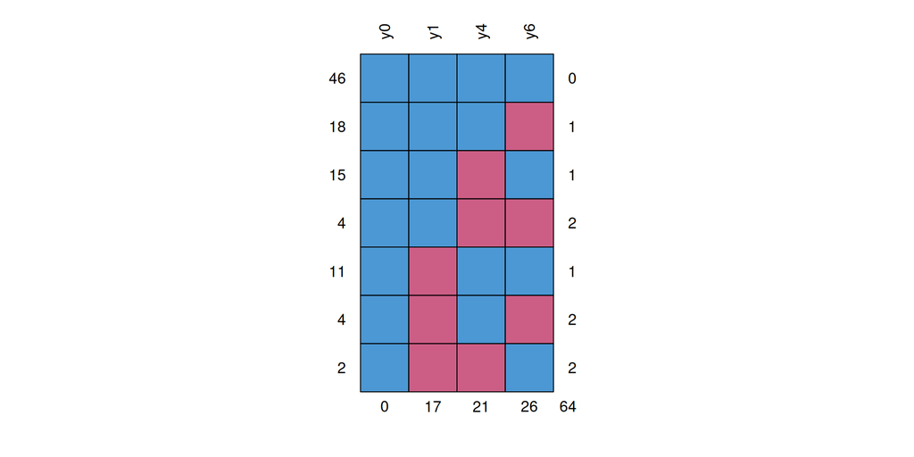

```
   y0 y1 y4 y6
46  1  1  1  1  0
18  1  1  1  0  1
15  1  1  0  1  1
4   1  1  0  0  2
11  1  0  1  1  1
4   1  0  1  0  2
2   1  0  0  1  2
    0 17 21 26 64
```

## Impute and Pool (Rubin’s Rules)

```r
imp_tlc <- mice(tlc_mice[, c("group", "y0", "y1", "y4", "y6")],
                m = 20, method = "pmm", printFlag = FALSE,
                seed = 667, maxit = 10)

# Scientific question: succimer vs placebo change in blood lead, baseline to week 6.
fit_tlc <- with(imp_tlc, lm(I(y6 - y0) ~ group))
pooled_tlc <- pool(fit_tlc)
summary(pooled_tlc)[, c("term", "estimate", "std.error", "statistic", "p.value")]
```

## Impute and Pool (Rubin’s Rules)

```
         term estimate std.error statistic     p.value
1 (Intercept)  -2.6976 0.9300027 -2.900637 0.004880514
2      groupS  -2.5285 1.3470638 -1.877046 0.064767117
```

## TLC: MI vs Complete-Case vs Truth

| Method | Succimer vs placebo (week 6 change) |
| --- | --- |
| **Truth** (full TLC data) | -3.152 |
| **Complete case** (46 kids) | -3.226 |
| **Multiple imputation** ($m=20$) | -2.528 (SE 1.347) |

## TLC: Manual Rubin’s Rules

```r
# Show pool() is not a black box: compute W, B, T by hand for the group effect.
fits_list <- lapply(1:20, function(k) lm(I(y6 - y0) ~ group, data = complete(imp_tlc, k)))
ests <- sapply(fits_list, function(f) coef(f)["groupS"])
ses  <- sapply(fits_list, function(f) summary(f)$coefficients["groupS", "Std. Error"])

m     <- 20
Q_bar <- mean(ests)                 # pooled point estimate
W_bar <- mean(ses^2)                # within-imputation variance
B     <- var(ests)                  # between-imputation variance
T_var <- W_bar + (1 + 1/m) * B      # Rubin total variance
r     <- (1 + 1/m) * B / W_bar      # relative increase in variance
fmi   <- (r + 2 / ((m - 1) + 3)) / (r + 1)  # fraction of missing information

cat("Q_bar (pooled):", round(Q_bar, 3), "\n")
```

## TLC: Manual Rubin’s Rules

```
Q_bar (pooled): -2.528
```

```r
cat("W_bar  (within):", round(W_bar, 4), "\n")
```

```
W_bar  (within): 1.4783
```

```r
cat("B      (between):", round(B, 4), "\n")
```

```
B      (between): 0.3202
```

```r
cat("T = W_bar + (1+1/m) B:", round(T_var, 4), "  SE =", round(sqrt(T_var), 3), "\n")
```

```
T = W_bar + (1+1/m) B: 1.8146   SE = 1.347
```

```r
cat("FMI:", round(fmi, 3), " (fraction of information lost to missingness)\n")
```

```
FMI: 0.259  (fraction of information lost to missingness)
```

# Part V (Day 2): MNAR Sensitivity Analysis

## Why Sensitivity Analysis?

MI and IPW-GEE are valid under **MAR**. But MAR **cannot be tested** from the observed data.

So after a MAR primary analysis, ask: **how would the conclusion change under MNAR?**

**Beyond FLW Ch. 18**

Pattern-mixture models, the Diggle-Kenward selection model, and the CCMV/NCMV/ACMV identifying restrictions are **not** developed in FLW Ch. 18. They are the broader MNAR literature (Molenberghs & Kenward, 2007; Little & Rubin, 2019). We present them as sensitivity tools and flag them as enrichment.

## Pattern-Mixture Models (sensitivity)

**Idea**: Stratify by **dropout pattern**, fit separate models, then **combine**.

$$f(Y, R) = f(Y \mid R) \cdot P(R)$$

The marginal distribution of $Y$ is a **mixture** over patterns.

## Defining Dropout Patterns

Common patterns based on **last observed time**:

| Pattern | Description |
| --- | --- |
| $d = 1$ | Dropout after time 1 |
| $d = 2$ | Dropout after time 2 |
| … | … |
| $d = T$ | Completer |

## Pattern-Mixture: Model Specification

For each pattern $d$:

$$Y_i \mid R_i = d \sim N(X_i \beta_d, \Sigma_d)$$

Marginalize over patterns:

$$E(Y) = \sum_{d} E(Y \mid R = d) \cdot P(R = d)$$

## Pattern-Mixture: Implementation

```r
# Define dropout pattern
dat_pm <- dat_mnar |>
  group_by(id) |>
  summarise(
    last_obs_time = max(time[observed]),
    trt = first(trt),
    .groups = "drop"
  ) |>
  mutate(pattern = factor(last_obs_time))

# Merge back
dat_pm_full <- dat_mnar |>
  left_join(dat_pm |> dplyr::select(id, pattern), by = "id") |>
  filter(observed)

table(dat_pm$pattern)
```

## Pattern-Mixture: Implementation

```
 0  1  2  3  4
76 39 19  7 59
```

## Fitting Pattern-Specific Models

```r
# Fit model within each pattern (for patterns with enough data)
patterns_with_data <- dat_pm_full |>
  group_by(pattern) |>
  summarise(n = n_distinct(id)) |>
  filter(n >= 10) |>
  pull(pattern)

fits_by_pattern <- lapply(patterns_with_data, function(p) {
  dat_p <- dat_pm_full |> filter(pattern == p)
  tryCatch({
    lme(y_obs ~ time * trt, random = ~ 1 | id, data = dat_p, method = "REML")
  }, error = function(e) NULL)
})
names(fits_by_pattern) <- patterns_with_data

# Extract treatment effects at final time
sapply(fits_by_pattern, function(fit) {
  if (is.null(fit)) return(NA)
  coef(summary(fit))["trt", "Value"]
})
```

## Fitting Pattern-Specific Models

```
        0         1         2         4
       NA -2.680627 -2.263105 -1.643335
```

## Combining Pattern-Specific Estimates

**The Key Step Students Often Miss**

To get a **marginal** treatment effect from pattern-mixture models, we must **average over patterns** weighted by pattern probabilities.

```r
# Calculate pattern weights (proportion of subjects in each pattern)
pattern_weights <- dat_pm |>
  count(pattern) |>
  mutate(weight = n / sum(n))

# Extract treatment effects and SEs from each pattern
extract_trt_effect <- function(fit) {
  if (is.null(fit)) return(c(estimate = NA, se = NA))
  coefs <- coef(summary(fit))
  c(estimate = coefs["trt", "Value"],
    se = coefs["trt", "Std.Error"])
}

pattern_effects <- bind_rows(
  lapply(names(fits_by_pattern), function(p) {
    eff <- extract_trt_effect(fits_by_pattern[[p]])
    data.frame(pattern = p, estimate = eff["estimate"], se = eff["se"])
  })
)

# Merge with weights
pattern_combined <- pattern_effects |>
  left_join(pattern_weights, by = "pattern") |>
  filter(!is.na(estimate))

# Weighted average treatment effect (marginal estimate)
marginal_estimate <- sum(pattern_combined$estimate * pattern_combined$weight) /
                     sum(pattern_combined$weight)

# Approximate SE using delta method (simplified)
marginal_se <- sqrt(sum((pattern_combined$weight * pattern_combined$se)^2)) /
               sum(pattern_combined$weight)

cat("Pattern-Mixture Model Results:\n")
```

## Combining Pattern-Specific Estimates

```
Pattern-Mixture Model Results:
```

```r
cat("================================\n")
pattern_combined |>
  mutate(across(c(estimate, se, weight), ~round(., 3))) |>
  print()
```

```
  pattern estimate    se  n weight
1       1   -2.681 0.773 39  0.195
2       2   -2.263 1.130 19  0.095
3       4   -1.643 0.608 59  0.295
```

```r
cat("\n\nMarginal Treatment Effect (CCMV assumption):\n")
```

```
Marginal Treatment Effect (CCMV assumption):
```

```r
cat("  Estimate:", round(marginal_estimate, 3), "\n")
```

```
  Estimate: -2.09
```

```r
cat("  SE:", round(marginal_se, 3), "\n")
```

```
  SE: 0.441
```

```r
cat("  95% CI: [", round(marginal_estimate - 1.96*marginal_se, 3), ",",
    round(marginal_estimate + 1.96*marginal_se, 3), "]\n")
```

```
  95% CI: [ -2.953 , -1.226 ]
```

```r
cat("\nComparison to truth:", round(fixef(fit_truth)["trt"], 3), "\n")
```

```
Comparison to truth: -2.091
```

## Identifying Restrictions

**Problem**: Cannot estimate $E(Y_{mis} \mid R = d)$ directly from data.

**Solution**: Apply **identifying restrictions** to extrapolate:

| Restriction | Assumption |
| --- | --- |
| CCMV | Complete Case Missing Value: use completer parameters |
| NCMV | Neighboring Case Missing Value: borrow from adjacent pattern |
| ACMV | Available Case Missing Value: weighted average |

## Identifying Restrictions: Detailed Explanation

**What Each Restriction Assumes**

**CCMV (Complete Case Missing Value):**

For subjects who dropped out at time $k$, assume their unobserved values at times $k, k+1, \ldots$ have the **same distribution as completers** at those times.

- Simple to implement: use completer-based parameters for all patterns
- Assumption: Dropouts would have behaved like completers after dropout
- This is often **optimistic** about dropouts

**NCMV (Neighboring Case Missing Value):**

For subjects who dropped out at time $k$, assume their unobserved value at time $k$ has the same distribution as subjects who dropped out at time $k+1$ (the next pattern).

- “Borrow” from the nearest pattern with observed data
- Less extreme than CCMV for early dropouts

**ACMV (Available Case Missing Value):**

A weighted combination of information from all patterns that observed each time point.

- Most complex to implement
- Often considered the most realistic “MAR-like” restriction

## Implementing CCMV Identifying Restriction

```r
# Under CCMV, we use completer model parameters for all dropout patterns
# This means we assume dropouts would have followed the same trajectory as completers

# Get completer pattern (last time point = 4 for 0-indexed times 0-4)
completer_fit <- fits_by_pattern[["4"]]

if (!is.null(completer_fit)) {
  # Extract completer model coefficients
  completer_coefs <- fixef(completer_fit)

  cat("CCMV Identifying Restriction:\n")
  cat("==============================\n")
  cat("Under CCMV, we assume dropouts would have had outcomes\n")
  cat("distributed like completers at unobserved time points.\n\n")
  cat("Completer model coefficients:\n")
  print(round(completer_coefs, 3))

  cat("\nUnder CCMV, marginal treatment effect = completer treatment effect\n")
  cat("Treatment effect:", round(completer_coefs["trt"], 3), "\n")
} else {
  cat("Completer pattern model did not converge.\n")
}
```

## Implementing CCMV Identifying Restriction

```
CCMV Identifying Restriction:
==============================
Under CCMV, we assume dropouts would have had outcomes
distributed like completers at unobserved time points.

Completer model coefficients:
(Intercept)        time         trt    time:trt
     18.796      -0.573      -1.643      -0.955

Under CCMV, marginal treatment effect = completer treatment effect
Treatment effect: -1.643
```

## Pattern-Mixture Summary

**Advantages**:

- Transparent about what is assumed
- Naturally accommodates MNAR

**Disadvantages**:

- Requires identifying restrictions (untestable)
- Many patterns with small samples

## Check Your Understanding: Part II

**Quick Self-Check**

1. **Pattern-Mixture Concept:** A study has 4 time points. Subject A drops out after time 2; Subject B completes all visits. Under pattern-mixture modeling, would these subjects share the same model parameters?
2. **Combining Estimates:** You have treatment effects of -2.0 (early dropouts, 30% of sample) and -3.0 (completers, 70% of sample). What is the marginal treatment effect under the weighting approach?
3. **CCMV Assumption:** Under CCMV, what are we assuming about subjects who dropped out early?

**Answers**

1. **No** - Pattern-mixture models fit separate models for each dropout pattern. Subject A contributes to the “dropout after time 2” model; Subject B contributes to the “completer” model. They may have different intercepts, slopes, and treatment effects.
2. $\text{Marginal} = 0.30 \times (-2.0) + 0.70 \times (-3.0) = -0.6 - 2.1 = -2.7$
3. Under CCMV, we assume that subjects who dropped out early would have had outcomes **distributed like completers** at the time points they missed. This is often optimistic because dropouts may actually be doing worse (or better) than completers at unobserved times.

## Selection Models (sensitivity)

**Beyond FLW Ch. 18**

Selection models, and the Diggle-Kenward model specifically, are not in FLW Ch. 18. They belong to the broader MNAR literature (Diggle & Kenward, 1994; Molenberghs & Kenward, 2007). Shown here as a second sensitivity lens.

Model the **joint distribution** of outcome and missingness as outcome times selection:

$$f(Y, R) = f(Y) \cdot P(R \mid Y)$$

The selection model specifies how missingness **depends on** $Y$.

## Selection Model: Specification

**Outcome model:**
$$Y_i \sim N(X_i \beta, \Sigma)$$

**Selection (dropout) model:**
$$\text{logit}[P(R_{ij} = 0 \mid Y)] = \gamma_0 + \gamma_1 Y_{ij} + \gamma_2 Y_{i,j-1} + \ldots$$

If $\gamma_1 \neq 0$, dropout depends on current (unobserved) outcome = **MNAR**. If dropout depends only on past observed $Y$, this is **MAR**.

## Diggle-Kenward Selection Model

A classic MNAR selection model (Diggle & Kenward, 1994):

$$\text{logit}[P(D_i = j \mid Y_i)] = \alpha_0 + \alpha_1 Y_{ij}$$

where $D_i$ is dropout time.

The model jointly estimates outcome and dropout parameters.

## Selection Model: Simulation Example

```r
# Selection-model intuition: contrast a naive observed-data fit with the truth.
# In practice a full selection model needs joint ML (e.g. SAS PROC NLMIXED).
#
# Illustrative MNAR DGP from Part I: dropout hazard rises with the current y.
# A MAR-style analysis of the observed data ignores that; the truth model uses
# the complete data (fit_truth was built in the shared setup chunk).
fit_mar <- lme(y_obs ~ time * trt, random = ~ 1 | id,
               data = dat_pm_full, method = "REML")

data.frame(
  Model = c("Truth (complete)", "MAR (observed)"),
  Intercept = round(c(fixef(fit_truth)[1], fixef(fit_mar)[1]), 3),
  Time = round(c(fixef(fit_truth)[2], fixef(fit_mar)[2]), 3),
  Trt = round(c(fixef(fit_truth)[3], fixef(fit_mar)[3]), 3),
  Time_x_Trt = round(c(fixef(fit_truth)[4], fixef(fit_mar)[4]), 3)
)
```

## Selection Model: Simulation Example

```
             Model Intercept   Time    Trt Time_x_Trt
1 Truth (complete)    20.122 -0.427 -2.091     -0.951
2   MAR (observed)    20.053 -0.624 -2.098     -0.929
```

## Selection Model: Simplified Working Example

**A Two-Step Approximation**

Full selection models require joint maximum likelihood, which is computationally complex. Here we show a simplified two-step approach for understanding the concept.

```r
# Step 1: Estimate the selection (dropout) model from observed data.
# Among subjects still in the study at time t-1, model whether they are
# observed at time t (R_it), using the previous observed response.
dat_dropout <- dat_mnar |>
  group_by(id) |>
  mutate(
    y_prev   = lag(y, 1),                       # previous (observed) Y
    prev_obs = lag(observed, default = TRUE),   # in the study at t-1?
    R        = as.integer(observed)             # observed at t?
  ) |>
  ungroup() |>
  filter(time > 0, prev_obs)                    # at-risk rows after baseline

# Fit selection (remaining-in-study) model
dropout_model <- glm(R ~ y_prev + time + trt,
                     data = dat_dropout,
                     family = binomial)

cat("Selection (Dropout) Model:\n")
```

## Selection Model: Simplified Working Example

```
Selection (Dropout) Model:
```

```r
cat("==========================\n")
cat("logit(P(dropout at t)) = beta0 + beta1*Y_{t-1} + beta2*time + beta3*trt\n\n")
```

```
logit(P(dropout at t)) = beta0 + beta1*Y_{t-1} + beta2*time + beta3*trt
```

```r
summary(dropout_model)$coefficients |> round(3)
```

```
            Estimate Std. Error z value Pr(>|z|)
(Intercept)    3.149      0.906   3.475    0.001
y_prev        -0.153      0.040  -3.814    0.000
time           0.257      0.118   2.182    0.029
trt           -0.085      0.236  -0.361    0.718
```

## Selection Model: Interpretation

```r
# The model is for REMAINING in the study (R = 1). The y_prev coefficient
# is the log-OR of staying per 1-unit increase in the previous response.
dropout_coefs <- coef(dropout_model)
or_remain <- exp(dropout_coefs["y_prev"])

cat("Selection Model Interpretation (modeling P(remain)):\n")
```

## Selection Model: Interpretation

```
Selection Model Interpretation (modeling P(remain)):
```

```r
cat("====================================================\n\n")
cat("Coefficient for previous Y (y_prev):", round(dropout_coefs["y_prev"], 3), "\n")
```

```
Coefficient for previous Y (y_prev): -0.153
```

```r
cat("  OR for remaining per +1 in Y_{t-1}:", round(or_remain, 3), "\n")
```

```
  OR for remaining per +1 in Y_{t-1}: 0.858
```

```r
cat("  -> OR for DROPPING per +1 in Y_{t-1}:", round(1 / or_remain, 3), "\n\n")
```

```
  -> OR for DROPPING per +1 in Y_{t-1}: 1.165
```

```r
if (dropout_coefs["y_prev"] < 0) {
  cat("  y_prev < 0: HIGHER previous Y -> LOWER odds of remaining,\n")
  cat("  i.e. subjects with higher outcomes are more likely to drop out.\n")
}
```

```
  y_prev < 0: HIGHER previous Y -> LOWER odds of remaining,
  i.e. subjects with higher outcomes are more likely to drop out.
```

```r
cat("\n  This uses PAST observed Y (so it is MAR-testable). It becomes MNAR\n")
```

```
  This uses PAST observed Y (so it is MAR-testable). It becomes MNAR
```

```r
cat("  only if the CURRENT, unobserved Y drives dropout, which cannot be\n")
```

```
  only if the CURRENT, unobserved Y drives dropout, which cannot be
```

```r
cat("  estimated from the observed data.\n\n")
```

```
  estimated from the observed data.
```

```r
cat("NOTE: a full selection model jointly estimates the outcome and selection\n")
```

```
NOTE: a full selection model jointly estimates the outcome and selection
```

```r
cat("models by maximum likelihood. This two-step version is for intuition only.\n")
```

```
models by maximum likelihood. This two-step version is for intuition only.
```

## Selection Model: Key Points

**Advantages**:

- Explicitly models the selection mechanism
- Can test sensitivity to MNAR assumptions

**Disadvantages**:

- Difficult to fit (joint likelihood)
- Highly sensitive to model specification
- Often poorly identified

## Check Your Understanding: Part III

**Quick Self-Check**

1. **Selection vs Pattern-Mixture:** Which factorization corresponds to the selection model?
   - 1. $f(Y, R) = f(Y | R) \cdot P(R)$
   - 2. $f(Y, R) = f(Y) \cdot P(R | Y)$
2. **MAR in Selection Models:** In the dropout model $\text{logit}[P(R=0 | Y)] = \gamma_0 + \gamma_1 Y_{current}$, what value of $\gamma_1$ would make this MAR instead of MNAR?
3. **Identifiability:** Why are selection models often poorly identified?

**Answers**

1. **(b)** - Selection models factor as $f(Y) \cdot P(R | Y)$: first model the outcome, then model how missingness depends on the outcome. Pattern-mixture models use factorization (a).
2. $\gamma_1 = 0$ - If dropout does not depend on the current (unobserved) outcome value, then missingness depends only on covariates and past observed values, which is MAR. Any $\gamma_1 \neq 0$ makes it MNAR.
3. Selection models are poorly identified because the key parameter $\gamma_1$ (dependence on unobserved Y) cannot be directly estimated from observed data. The unobserved Y values are… unobserved! This means the model relies heavily on distributional assumptions and extrapolation, making results sensitive to model specification.

## Sensitivity Analysis Approaches

| Approach | Description |
| --- | --- |
| **Tipping point** | How extreme must MNAR be to change conclusions? |
| **Delta adjustment** | Add offset $\delta$ to imputed values for dropouts |
| **Pattern-mixture with varying restrictions** | Try CCMV, NCMV, etc. |
| **Selection model with varying $\gamma$** | Vary the MNAR parameter |

## Delta-Adjustment Method

**Idea**: Impute under MAR, then shift imputed values by $\delta$.

- $\delta = 0$: MAR assumption
- $\delta > 0$: Dropouts would have had higher values
- $\delta < 0$: Dropouts would have had lower values

## Delta-Adjustment: Implementation

```r
# Reshape the illustrative MNAR data to wide for mice
dat_wide <- dat_mnar |>
  dplyr::select(id, time, trt, y_obs) |>
  pivot_wider(names_from = time, values_from = y_obs, names_prefix = "y")

# Impute ONCE under MAR, reuse for every delta (faster and self-consistent)
m_imp <- 10
imp_base <- mice(dat_wide, m = m_imp, method = "pmm", printFlag = FALSE, seed = 123)
imp_long_all <- complete(imp_base, action = "long") |>
  pivot_longer(starts_with("y"), names_to = "tv", values_to = "y") |>
  mutate(time = as.numeric(gsub("y", "", tv)))

# Flag which (id, time) cells were originally missing (so delta hits only imputed)
orig_missing <- dat_wide |>
  pivot_longer(starts_with("y"), names_to = "tv", values_to = "y") |>
  mutate(time = as.numeric(gsub("y", "", tv)), was_missing = is.na(y)) |>
  dplyr::select(id, time, was_missing)

imp_flagged <- imp_long_all |> left_join(orig_missing, by = c("id", "time"))

# Apply a delta offset to imputed cells, refit, and pool with Rubin's rules
analyze_with_delta <- function(delta) {
  imp_flagged |>
    mutate(y_adj = ifelse(was_missing, y + delta, y)) |>
    group_by(.imp) |>
    do(tidy(lm(y_adj ~ time * trt, data = .))) |>
    ungroup() |>
    group_by(term) |>
    summarise(
      # std.error first: it needs the full per-imputation `estimate` vector for the
      # between-imputation variance var(estimate). Collapsing estimate first would
      # make var() see a scalar and return NA (dplyr evaluates summarise() in order).
      std.error = sqrt(mean(std.error^2) + (1 + 1/m_imp) * var(estimate)),
      estimate  = mean(estimate),
      .groups   = "drop"
    ) |>
    mutate(delta = delta)
}

deltas <- c(-2, -1, 0, 1, 2)
sensitivity_results <- bind_rows(lapply(deltas, analyze_with_delta))

sensitivity_results |>
  filter(term == "trt") |>
  dplyr::select(delta, estimate, std.error) |>
  mutate(
    lower = estimate - 1.96 * std.error,
    upper = estimate + 1.96 * std.error
  )
```

## Delta-Adjustment: Implementation

```
# A tibble: 5 × 5
  delta estimate std.error lower upper
  <dbl>    <dbl>     <dbl> <dbl> <dbl>
1    -2    -2.08     0.364 -2.80 -1.37
2    -1    -2.13     0.359 -2.84 -1.43
3     0    -2.18     0.360 -2.89 -1.48
4     1    -2.23     0.368 -2.95 -1.51
5     2    -2.28     0.381 -3.02 -1.53
```

## Visualizing Sensitivity Analysis

```r
sens_trt <- sensitivity_results |>
  filter(term == "trt") |>
  mutate(
    lower = estimate - 1.96 * std.error,
    upper = estimate + 1.96 * std.error
  )

ggplot(sens_trt, aes(x = delta, y = estimate)) +
  geom_point(size = 3) +
  geom_errorbar(aes(ymin = lower, ymax = upper), width = 0.1) +
  geom_hline(yintercept = 0, linetype = 2, color = "red") +
  geom_hline(yintercept = fixef(fit_truth)["trt"], linetype = 3, color = "blue") +
  labs(
    title = "Sensitivity Analysis: Treatment Effect by Delta",
    subtitle = "Blue dashed = true effect; Red dashed = null",
    x = expression(delta ~ "(adjustment to imputed values)"),
    y = "Estimated Treatment Effect"
  ) +
  theme_minimal()
```

## Visualizing Sensitivity Analysis

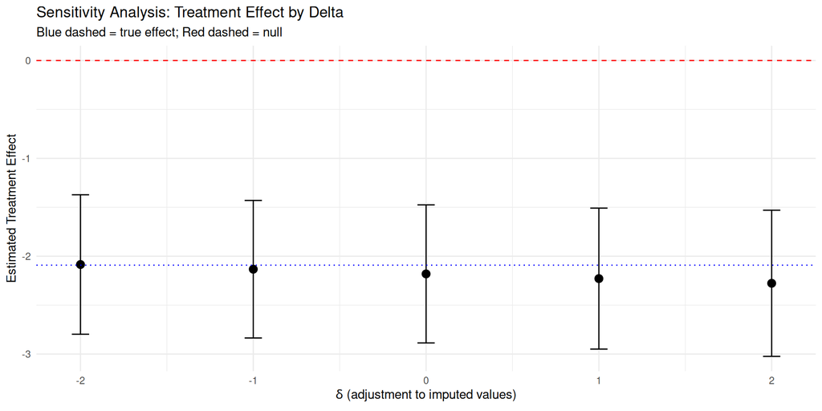

## Tipping Point Analysis

**Question**: At what value of $\delta$ does the treatment effect become non-significant?

This tells us how extreme MNAR must be to overturn our conclusions.

## Tipping Point: Interpretation

```r
# Find tipping point (where CI includes 0)
sens_trt |>
  mutate(
    significant = (lower > 0) | (upper < 0),
    direction = ifelse(estimate > 0, "positive", "negative")
  ) |>
  dplyr::select(delta, estimate, lower, upper, significant)
```

If tipping point requires implausibly large $\delta$, results are **robust**.

## Tipping Point: Interpretation

```
# A tibble: 5 × 5
  delta estimate lower upper significant
  <dbl>    <dbl> <dbl> <dbl> <lgl>
1    -2    -2.08 -2.80 -1.37 TRUE
2    -1    -2.13 -2.84 -1.43 TRUE
3     0    -2.18 -2.89 -1.48 TRUE
4     1    -2.23 -2.95 -1.51 TRUE
5     2    -2.28 -3.02 -1.53 TRUE
```

## Check Your Understanding: Part V

**Quick Self-Check**

1. **Delta Interpretation:** In the delta-adjustment sensitivity analysis, what does $\delta = -2$ mean in practical terms?
2. **Tipping Point:** Your MAR analysis shows treatment effect = -3.0 (95% CI: -4.5, -1.5), significant at p < 0.001. The tipping point occurs at $\delta = 1.5$. How do you interpret this?
3. **Plausibility:** How would you assess whether a tipping point value of $\delta$ is clinically plausible?

**Answers**

1. $\delta = -2$ means we assume that **dropouts would have had outcomes 2 units LOWER** than what MAR imputation predicts. If higher values are better (e.g., quality of life), this assumes dropouts are doing worse than MAR suggests.
2. The tipping point at $\delta = 1.5$ means that if dropouts had outcomes **1.5 units higher** than MAR predicts, the treatment effect would become non-significant. Since this is a relatively small shift compared to the effect size (3.0 units), the result has **moderate robustness**. Clinical judgment is needed to assess if $\delta = 1.5$ is plausible.
3. To assess plausibility:
   - Compare $\delta$ to the outcome’s standard deviation (is it a small or large shift?)
   - Consider clinical meaning (would dropouts realistically differ by this amount?)
   - Examine reasons for dropout (do they suggest better or worse outcomes?)
   - Look at observed differences between completers and early dropouts at shared timepoints

# Part VI (Day 2): Practical Guidance and Summary

## Decision Framework

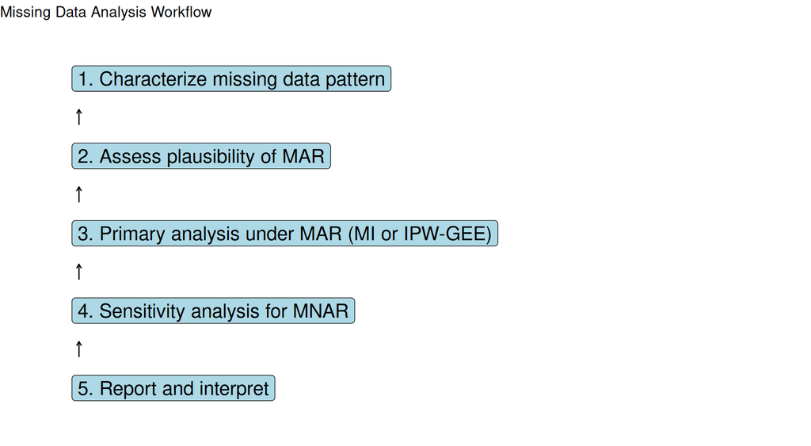

## Step 1: Characterize Missing Data

- Document amount and pattern of missingness
- Compare baseline characteristics: completers vs dropouts
- Examine timing and predictors of dropout

## Step 2: Assess MAR Plausibility

| Evidence for MAR | Evidence Against |
| --- | --- |
| Dropout predicted by observed baseline/time-varying | Clinical reasons suggest dropout related to unobserved outcomes |
| No strong theoretical reason for MNAR | Treatment side effects causing dropout |

## Step 3: Primary Analysis Under MAR

**For continuous outcomes:**

- Mixed models (ML/REML) are valid under MAR
- GEE with appropriate weighting
- Multiple imputation with careful model specification

## Step 4: Sensitivity Analysis

Even if MAR seems plausible:

- Conduct pattern-mixture or selection model analysis
- Perform tipping point analysis
- Report range of estimates under different assumptions

## Step 5: Reporting Recommendations

| Element | Description |
| --- | --- |
| Missing data summary | Rates, patterns, predictors |
| Primary analysis | Method, assumptions |
| Sensitivity analysis | Methods tried, range of results |
| Interpretation | Robustness of conclusions |

## Common Mistakes to Avoid

| Mistake | Better Approach |
| --- | --- |
| Complete case analysis only | Use all available data |
| Assuming MCAR without testing | Assess predictors of missingness |
| Ignoring MNAR possibility | Always do sensitivity analysis |
| Single imputation | Use multiple imputation |
| Not reporting missing data details | Document thoroughly |

## Software Summary

| Task | R Package/Function |
| --- | --- |
| Mixed models under MAR | `nlme::lme`, `lme4::lmer` |
| GEE / IPW-GEE | `geepack::geeglm(..., weights = w)` |
| Multiple imputation | `mice::mice` then `pool()` |
| Pattern-mixture (sensitivity) | Custom coding or `JointAI` |
| Selection models (sensitivity) | `JM`, `mmrm`, custom |

## SAS Reference: Multiple Imputation (FLW 18.2/18.6)

```sas
/* Step 1: impute m = 20 completed data sets (wide TLC data) */
proc mi data=tlc nimpute=20 seed=667 out=tlc_imp;
  class group;
  var y0 y1 y4 y6 group;
  fcs reg;                 /* fully conditional specification (chained eqns) */
run;

/* Step 2: analyze each completed data set; outest=cov keeps the covariance */
proc reg data=tlc_imp outest=est covout noprint;
  by _Imputation_;
  model chg6 = group;      /* chg6 = y6 - y0 created in a data step */
run;

/* Step 3: pool with Rubin's rules */
proc mianalyze data=est;
  modeleffects Intercept group;
run;
```

## SAS Reference: IPW-GEE (FLW 18.3/18.7)

```sas
/* Step 1: stacked data set, model probability of remaining (R = 1) */
proc logistic data=stacked descending;
  class time;
  model R = time dose yprev;     /* past observed response predicts staying */
  output out=pihat p=pi_hat;     /* fitted pi_ij */
run;

/* Step 2: cumulative-product weight w_ij = 1 / (pi_i1*...*pi_ij) in a data step */
/*         (computed by id, then merged back onto the analysis data)            */

/* Step 3: weighted GEE under working independence (required for weights) */
proc genmod data=analysis descending;
  class id time;
  weight w;                       /* inverse-probability weights */
  model y = time dose / dist=bin link=logit;
  repeated subject=id / type=ind; /* working independence */
run;
```

## Common Mistakes in MNAR and Sensitivity Analysis

**Errors to Avoid**

| # | Mistake | Correct Approach |
| --- | --- | --- |
| 1 | Claiming data are MAR without justification | MAR is an assumption; assess predictors of missingness, but acknowledge it cannot be verified |
| 2 | Skipping sensitivity analysis | Always conduct sensitivity analysis, even if MAR seems plausible |
| 3 | Pattern-mixture without combining step | Must weight pattern-specific estimates by pattern proportions for marginal inference |
| 4 | Using single imputation | Always use multiple imputation ($m \geq 20$) to capture uncertainty |
| 5 | Interpreting tipping point without clinical context | Evaluate whether the tipping point $\delta$ is clinically plausible |
| 6 | Ignoring selection model limitations | Selection models are poorly identified; use for sensitivity, not definitive answers |
| 7 | MI with incomplete imputation model | Include auxiliary variables; ensure imputation model is at least as rich as analysis model |
| 8 | Assuming MNAR = “analysis is hopeless” | MNAR means we need sensitivity analysis, not that we cannot make inference |
| 9 | Reporting only one analysis | Report MAR analysis AND sensitivity analysis range |
| 10 | Forgetting the FMI | Report fraction of missing information; helps assess impact of missingness |

## Interpreting MNAR Sensitivity Results

**How to Present Your Findings**

**Example Write-Up:**

> “Under the MAR assumption, the treatment effect was estimated as -3.2 units (95% CI: -4.5, -1.9, p < 0.001). We conducted sensitivity analysis using delta-adjustment to explore departures from MAR. The tipping point analysis showed that the treatment effect would become non-significant only if dropouts had outcomes at least 2.5 units higher than predicted under MAR (delta = 2.5). Given that the outcome SD is approximately 3.0 units, this represents a shift of nearly one standard deviation, which we consider clinically implausible based on exit interview data suggesting dropouts were, if anything, doing worse. We therefore conclude that the treatment effect is robust to plausible departures from MAR.”

**Key Elements:**

1. Report MAR analysis as primary
2. Describe sensitivity analysis method
3. Report tipping point in interpretable units
4. Assess clinical plausibility
5. State your conclusion about robustness

**Golden Rule for MNAR Analysis**

**Sensitivity analysis is not optional.** Since MNAR cannot be tested from observed data, you must:

1. Conduct your primary analysis under MAR (the most plausible “ignorable” assumption)
2. Explicitly test robustness to MNAR through sensitivity analysis
3. Report the range of conclusions under plausible MNAR scenarios
4. Let clinical/scientific judgment inform what “plausible” means

If your conclusion holds across the plausible range, it is robust. If it changes, acknowledge the uncertainty.

## Key Takeaways

1. **FLW Ch. 18 = two co-primary methods**: multiple imputation and IPW-GEE, both valid under MAR
2. **Multiple imputation**: impute $m$ times, analyze, pool with $T = \bar W + (1 + 1/m)B$; handles missing covariates and auxiliary variables
3. **IPW-GEE**: reweight observed responses by $1/\prod_j \pi_{ij}$ to fix MAR dropout where standard GEE needs MCAR
4. **Pattern-mixture and selection models** are MNAR **sensitivity** tools (beyond Ch. 18 proper), not the primary analysis
5. **Sensitivity analysis is essential**: conclusions should not hinge on the untestable MAR assumption. Report transparently.

## Course Wrap-Up: What We Covered

| Topic | Chapters |
| --- | --- |
| Longitudinal data structures | 1-2 |
| Linear models for longitudinal data | 3-6 |
| Covariance modeling | 7-9 |
| Mixed-effects models | 8-9 |
| Generalized linear models and GLMMs | 11, 14 |
| Marginal models and GEE | 12-13 |
| Missing data | 17-18 |

## Longitudinal Analysis: The Big Picture

1. **Choose the right model** for your research question:
   - Population-average effects: Marginal/GEE
   - Subject-specific trajectories: Mixed models
2. **Model the covariance** appropriately
3. **Handle missing data** with care
4. **Validate assumptions** through diagnostics

## Final Thoughts

Longitudinal data analysis requires careful attention to:

- **Correlation structure** within subjects
- **Missing data** mechanisms and their implications
- **Model interpretation** (marginal vs conditional)
- **Sensitivity** of conclusions to assumptions

## References and Further Reading

- Fitzmaurice, Laird & Ware (2011). *Applied Longitudinal Analysis*, 2nd ed. Ch. 17-18 (missing data and dropout).
- Rubin (1987). *Multiple Imputation for Nonresponse in Surveys* (Rubin’s combining rules).
- van Buuren (2018). *Flexible Imputation of Missing Data*, 2nd ed. (the `mice` reference).
- Robins, Rotnitzky & Zhao (1995). Inverse-probability weighting for longitudinal data.
- Diggle & Kenward (1994); Molenberghs & Kenward (2007). *Missing Data in Clinical Studies* (selection/pattern-mixture, beyond FLW Ch. 18).
- Little & Rubin (2019). *Statistical Analysis with Missing Data*, 3rd ed.

## Thank You!

Questions?

Course materials available on the course website.

Good luck with your research!